# TAREA 4 R

library(tidyverse) library(gapminder) library(dplyr)

Construya la variable “diamonds” que contenga la lectura del CSV, luego explore el data frame con la función str()

```r
str(diamonds)
```

```
spec_tbl_df [1,000 x 10] (S3: spec_tbl_df/tbl_df/tbl/data.frame)
 $ carat  : num [1:1000] 0.31 1.5 0.9 1.01 0.33 1.08 1.07 0.33 0.44 1 ...
 $ cut    : chr [1:1000] "Ideal" "Good" "Premium" "Ideal" ...
 $ color  : chr [1:1000] "G" "G" "H" "F" ...
 $ clarity: chr [1:1000] "VS1" "SI2" "VS2" "VS2" ...
 $ depth  : num [1:1000] 62.4 64.3 62.8 60.9 63.2 62 61.6 59.5 62 58.6 ...
 $ table  : num [1:1000] 55 57 58 58 56 55 58 59 57 61 ...
 $ price  : num [1:1000] 802 8190 3810 7411 1109 ...
 $ x      : num [1:1000] 4.35 7.29 6.17 6.43 4.45 6.62 6.6 4.53 4.87 6.57 ...
 $ y      : num [1:1000] 4.33 7.2 6.13 6.47 4.44 6.57 6.56 4.48 4.91 6.5 ...
 $ z      : num [1:1000] 2.71 4.66 3.86 3.93 2.81 4.09 4.05 2.68 3.02 3.83 ...
 - attr(*, "spec")=
  .. cols(
  ..   carat = col_double(),
  ..   cut = col_character(),
  ..   color = col_character(),
  ..   clarity = col_character(),
  ..   depth = col_double(),
  ..   table = col_double(),
  ..   price = col_double(),
  ..   x = col_double(),
  ..   y = col_double(),
  ..   z = col_double()
  .. )
```

**1. DISPERSION**  
1.1 Construya un gráfico de dispersión colocando en la estética *carat* (eje x) versus *price*, luego devuelva el gráfico

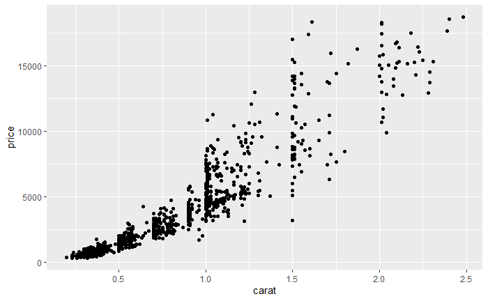

1.2 Edite la estética y mapée el color con la variable *clarity*  
1.3 Devuelva el gráfico on ésta modificación

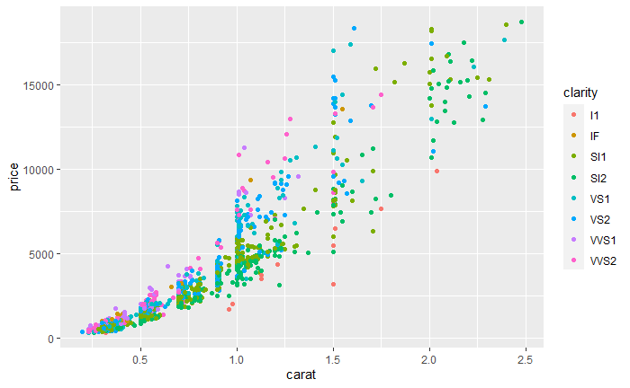

**2. HISTOGRAMA**  
2.1 Construya el tipo de geometría histograma para la variable *price*. Configure el parámetro *bins* con el valor 40 y devuelva el gráfico.

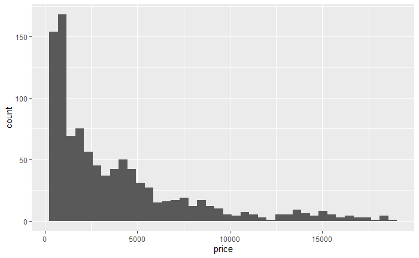

2.2 Agregue una escala logarítmica de base 10 y devuelva el gráfico para ver la diferencia.

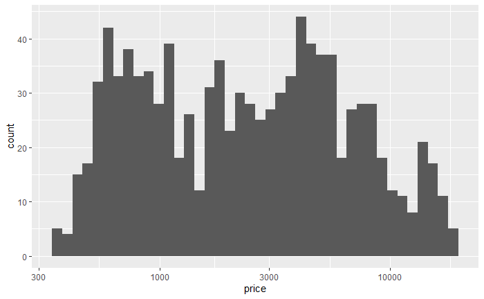

**3. BOXPLOTS**  
3.1 Construya un gráfico de cajas colocando en la estética la variable cut (eje x) versus price (eje y). Agruegue una escala logaritimica por defecto y por último devuelva el gráfico.

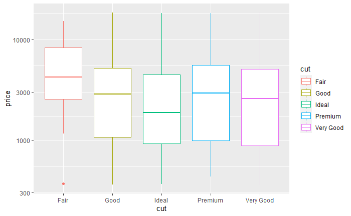

3.2 Edite el color de cada caja con el parametro *fill* dentro la estética y asignando la variable *cut*. Por último devuelva el gráfico

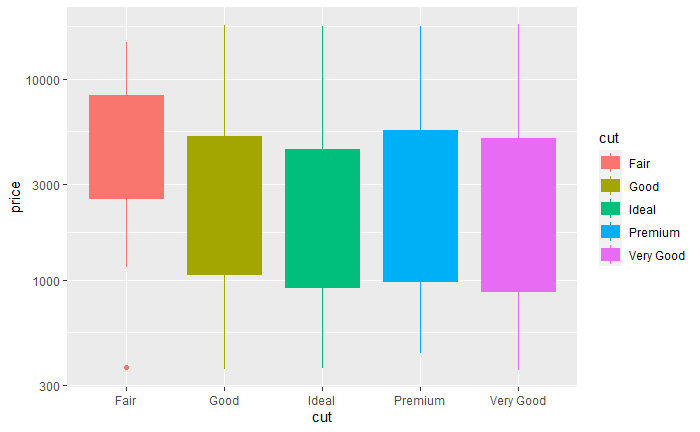

**4. FACETING**  
4.1 Filtre *diamonds* por la variable *price* que sea mayor a 1000 y por *cut* que contenga las categorías *Good, Ideal, premium*. Luego asigne el resultado a la variable *filtered_price*. Dado que *cut* debe tomar en cuenta tres categorias específicas puede hacer uso del pipe %in%. a continuación un ejemplo de su uso:

filter(var %in% c(“value1”,“value2”,“value3”))

| carat | cut | color | clarity | depth | table | price | x | y | z |
| --- | --- | --- | --- | --- | --- | --- | --- | --- | --- |
| 1.50 | Good | G | SI2 | 64.3 | 57.0 | 8190 | 7.29 | 7.20 | 4.66 |
| 0.90 | Premium | H | VS2 | 62.8 | 58.0 | 3810 | 6.17 | 6.13 | 3.86 |
| 1.01 | Ideal | F | VS2 | 60.9 | 58.0 | 7411 | 6.43 | 6.47 | 3.93 |
| 1.08 | Ideal | G | VS1 | 62.0 | 55.0 | 6779 | 6.62 | 6.57 | 4.09 |
| 1.07 | Premium | G | SI1 | 61.6 | 58.0 | 5453 | 6.60 | 6.56 | 4.05 |
| 0.44 | Ideal | H | IF | 62.0 | 57.0 | 1255 | 4.87 | 4.91 | 3.02 |
| 1.00 | Premium | G | VS1 | 58.6 | 61.0 | 6989 | 6.57 | 6.50 | 3.83 |
| 1.30 | Premium | J | SI2 | 61.1 | 61.0 | 5140 | 7.00 | 6.95 | 4.26 |
| 1.11 | Premium | E | SI2 | 61.0 | 60.0 | 4177 | 6.68 | 6.66 | 4.07 |
| 0.51 | Ideal | E | SI2 | 62.7 | 53.0 | 1265 | 5.12 | 5.09 | 3.20 |

[output cut: 536 more lines]

4.2 Utilice la variable *filtered_price* para construir un gráfico de barras, en la estética configure x=cut, y=depth

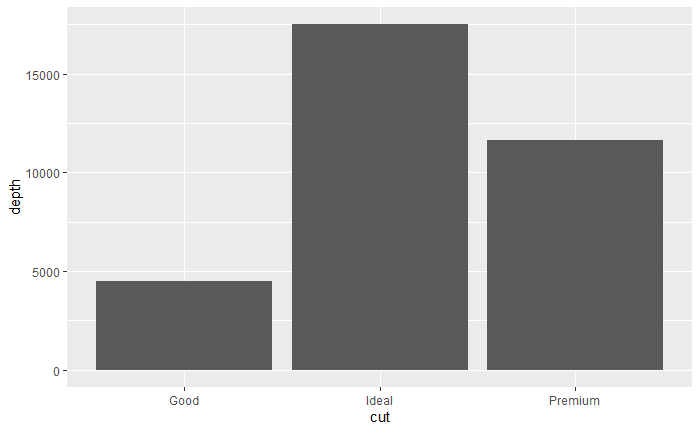

4.3 Por último aplique *faceting* para la variable *clarity* y devuelva la parcela de gráficos.

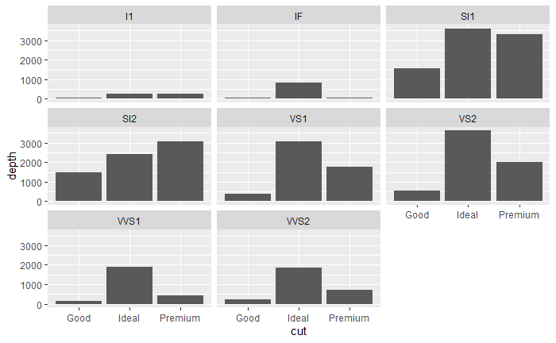

4.4 Edite la estética y configure el parámetro *fill* con la variable *clarity*. Luego devuelva la parcela de gráficos con ésta modificación.

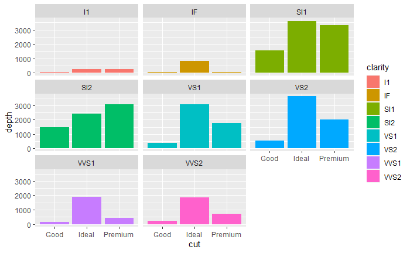

**GROUPING AND SUMMARIZING**  
1. Utilice *diamonds* para construir un agrupamiento por la variable *cut*, luego aplique *summarize* para encontrar la media de las variables *x,y,z* (los nombres de los valores sumarizados serán *mediaX,mediaY,mediaZ*, respectivamente). Asigne el resultado a la variable *median_dimension_diamond* por último imprima la variable.

| cut | mediaX | mediaY | mediaZ |
| --- | --- | --- | --- |
| Fair | 6.240 | 6.10 | 4.060 |
| Good | 5.890 | 5.93 | 3.670 |
| Ideal | 5.305 | 5.31 | 3.275 |
| Premium | 5.980 | 5.94 | 3.650 |
| Very Good | 5.665 | 5.71 | 3.530 |

2. Uilice *diamonds* para filtrar por la variable *cut* igual a *Premium*. Luego agrupe por la variable *clarity* y utilice *summarize* para encontrar minimoy máximo de price (los nombres de los valores umarizados serán *minPrice* y *maxPrice*, respectivamente). Asigne el resultado a la variable *cut_premium* e imprima el valor de la variable.

| clarity | minPrice | maxPrice |
| --- | --- | --- |
| I1 | 2046 | 9905 |
| IF | 694 | 1020 |
| SI1 | 500 | 18295 |
| SI2 | 434 | 16783 |
| VS1 | 523 | 17642 |
| VS2 | 454 | 17433 |
| VVS1 | 552 | 11279 |
| VVS2 | 698 | 8722 |

3. Construya un gráfico de barras y utilice *cut_premium* como set de datos, configure *x=clarity, y=maxPrice* y el color de relleno (*fill*) con la variable *clarity*. Por último devuelva el gráfico.

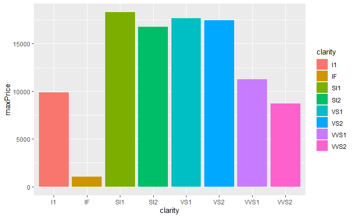